# Red Wine Exploration by Xiaoyu Chen

Next, let’s explore density with relations to fixed.acidity, sugar, chlorides and pH.

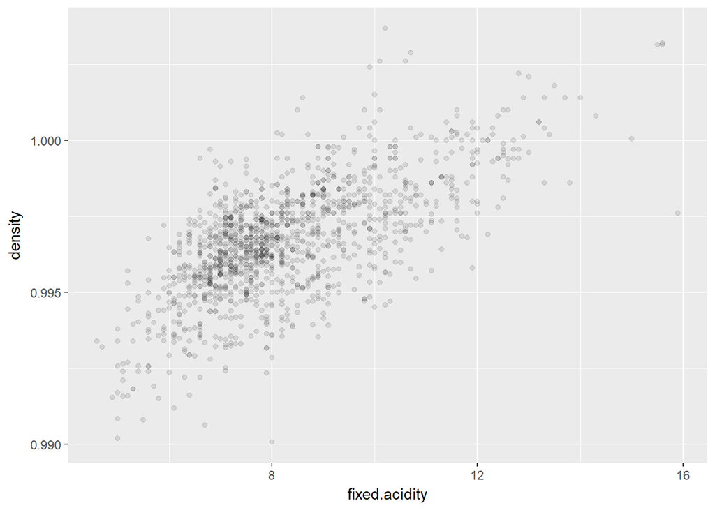

```
##
## Call:
## lm(formula = density ~ fixed.acidity, data = df)
##
## Residuals:
##        Min         1Q     Median         3Q        Max
## -0.0064150 -0.0007590  0.0001003  0.0009360  0.0056186
##
## Coefficients:
##                Estimate Std. Error t value Pr(>|t|)
## (Intercept)   9.907e-01  1.841e-04 5383.00   <2e-16 ***
## fixed.acidity 7.211e-04  2.168e-05   33.26   <2e-16 ***
## ---
## Signif. codes:  0 '***' 0.001 '**' 0.01 '*' 0.05 '.' 0.1 ' ' 1
##
## Residual standard error: 0.001388 on 1357 degrees of freedom
## Multiple R-squared:  0.4492, Adjusted R-squared:  0.4488
## F-statistic:  1107 on 1 and 1357 DF,  p-value: < 2.2e-16
```

Density is highly correlated with fixed.acidity. About 45% of density could be explained by fixed.acidity based on R^2.

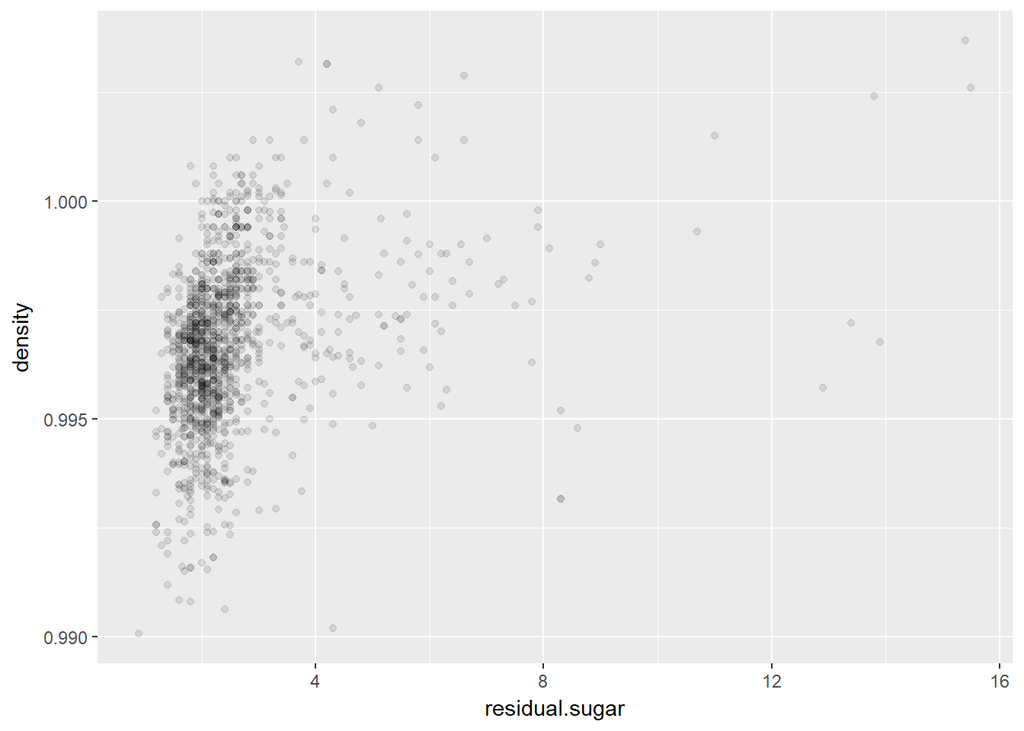

Let’s zoom in the scatter plot.

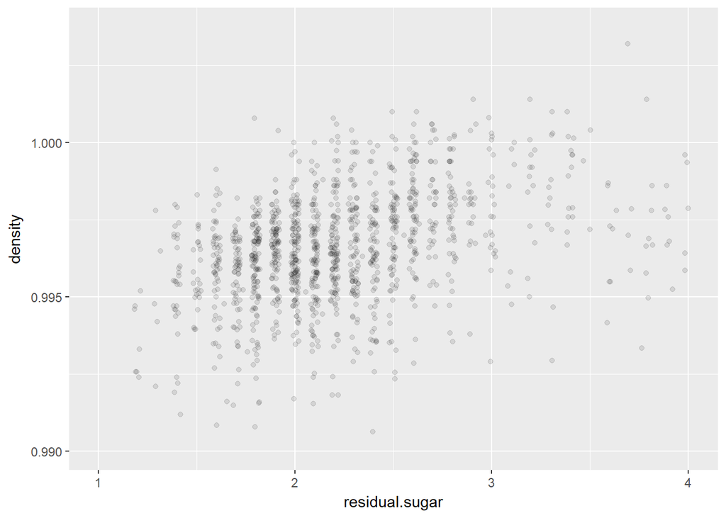

Density goes upward as residual.sugar increases and that makes sense. We also notice there are vertical bands along residual.sugar values.

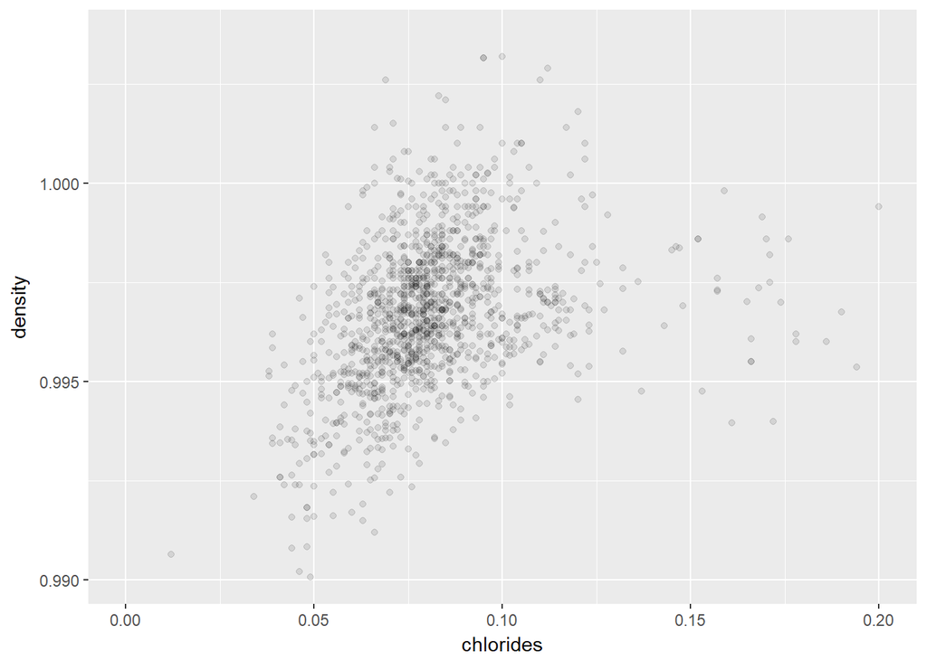

Similarly, density increases as chlorides increase. That makes sense since sugar and salt could increase density in normal life.

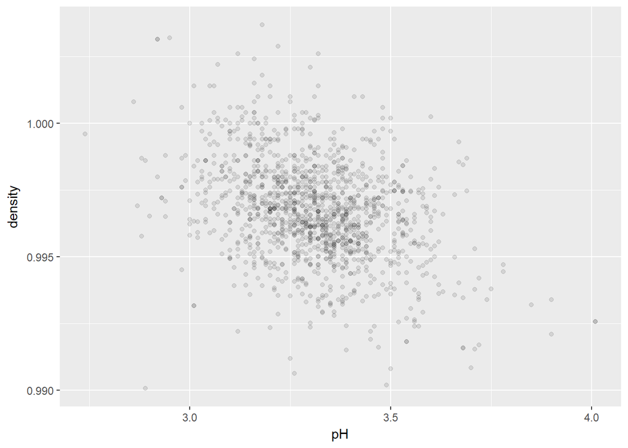

Density tends to be lower as pH grows.

Next we will check sulphates with free.sulfur.dioxide, volatile.acidity and chlorides.

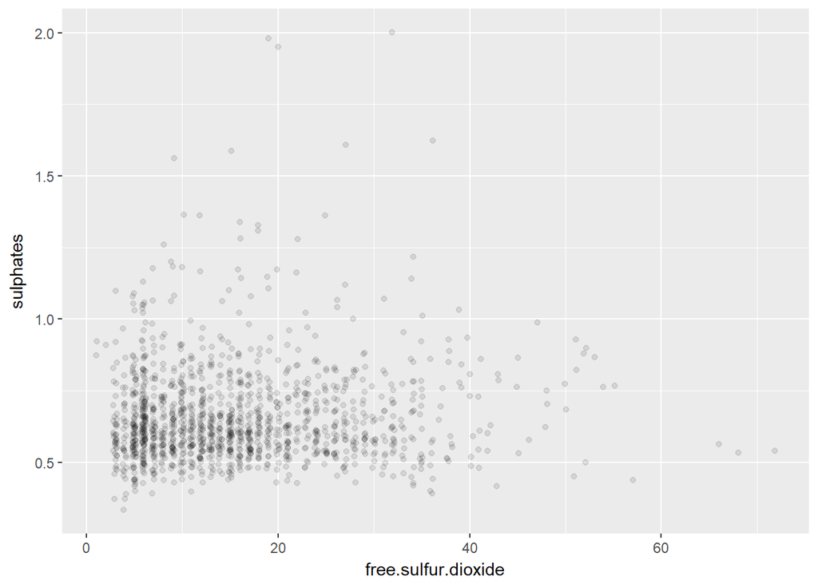

Like mentioned before, sulphates and free.sulfur.dioxide are still lack of correlations from scatter plot.

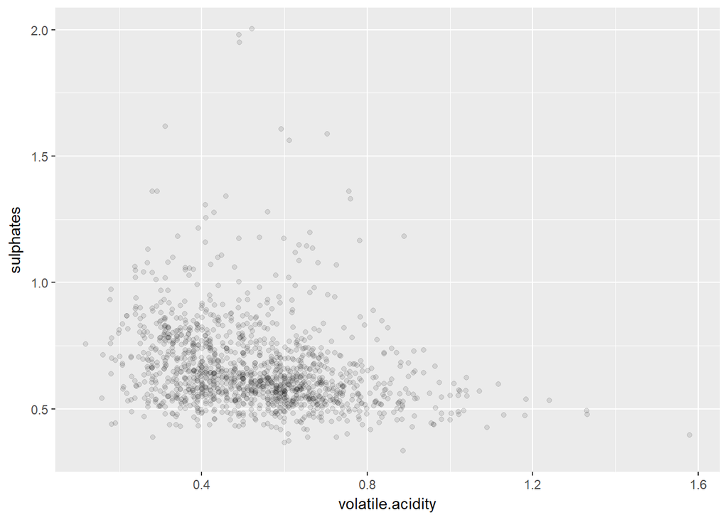

There is a slight correlation between volatile.acidity and sulphates.

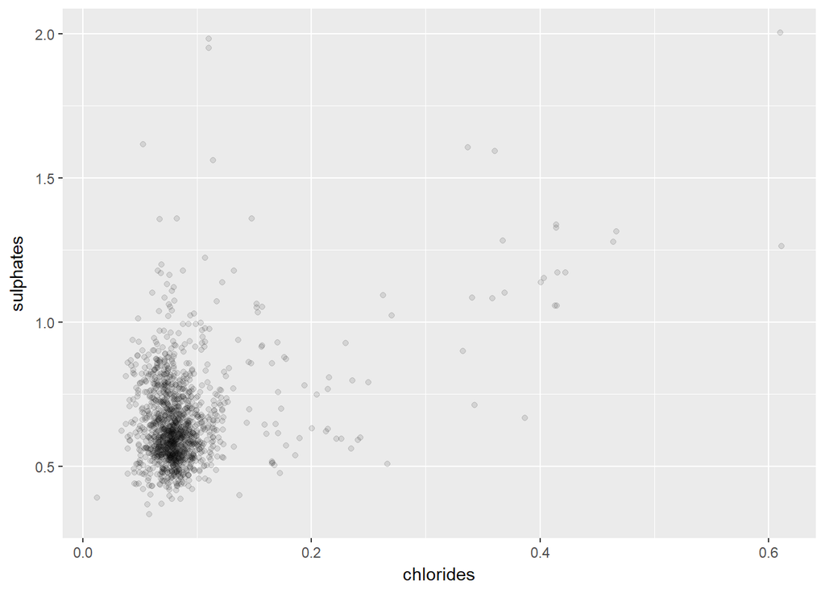

Let’s take a closer look.

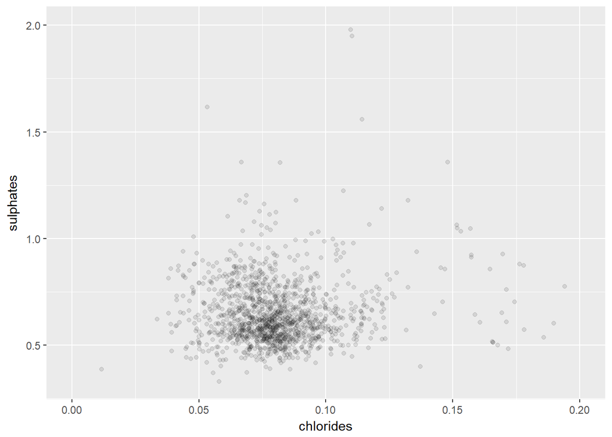

Sulphates and chlorides have a correlation 0.3946. Overall, sulphates grows as chlorides increases. However, if we take a closer look at the most data in the middle, it looks hard to find relation between them.

# Bivariate Analysis

### Talk about some of the relationships you observed in this part of the investigation. How did the feature(s) of interest vary with other features in the dataset?

Alcohol and volatile.acidity moderately correlate with quality. As alcohol increases, the quality gets more chance to be higher from scatter plot. On the contrary, the quality gets less chance at higher levels when volatile.acidity increases. We also notice that many wines having same levels of volatile.acidity or alcohol are scored differently.

Based on R^2 values, alcohol can explain 23% of the variance in quality and volatile.acidity explains 16%.

There is no any obvious correlation between alcohol and volatile.acidity from scatter plot.

In addition, there is a correlation between sulphates and quality as well. Citric.acid and density only show slight correlation with quality.

One intersting finding is the wines with more than 50 ppm of free.sulfur.dioxide are having not bad quality scores from 5 to 7.

### Did you observe any interesting relationships between the other features (not the main feature(s) of interest)?

Both bound and free sulfur dioxide have large correlations with total sulfur dioxide, which makes sense. Bound sulfur dioxide and free are moderately correlated.

Alcohol nagatively correlates to density, slightly positively correlates to pH, and slightly negatively to chlorides.

Citric.acid correlates with both fixed.acidity and volatile.acidity. The relationship between citric.acid and fixed.acidity is exponential rather than linear.

Both citric.acid and fixed.acidity negatively correlate with pH, and volatile.acidity positively correlates with pH.

Density correlates with fixed.acidity the most. At the same time, density clearly correlates with chlorides, slightly correlates with residual.sugar and pH.

Sulphates don’t show correlation with free.sulfur.dioxide, but the scatter plot displays slight negative correlation between sulphates and volatile.acidity.

### What was the strongest relationship you found?

Fixed.acidity is strongly and positively coreelated with density. About 45% of density could be explained by fixed.acidity based on R^2.

# Multivariate Plots Section

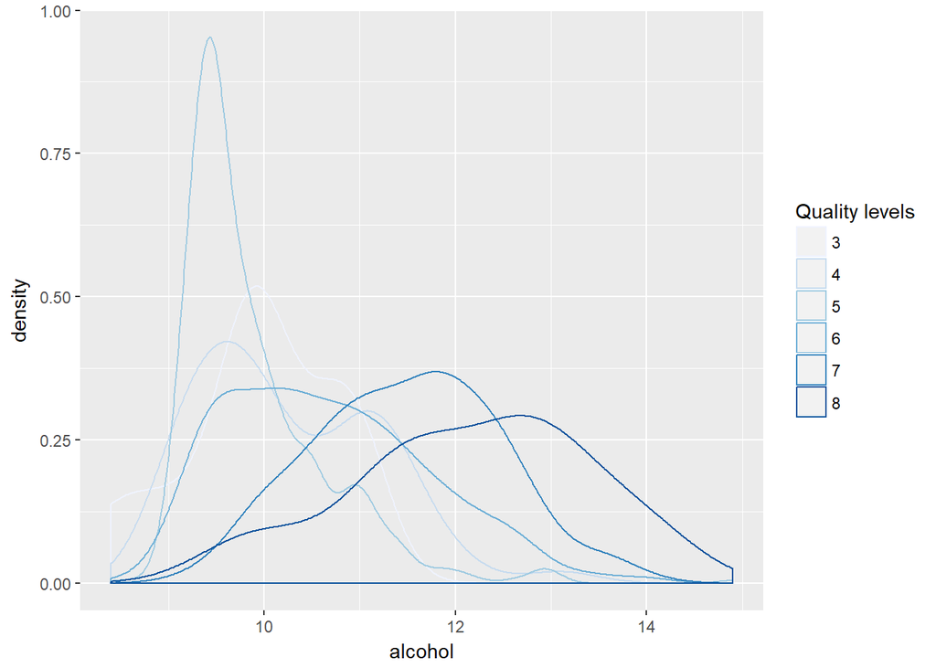

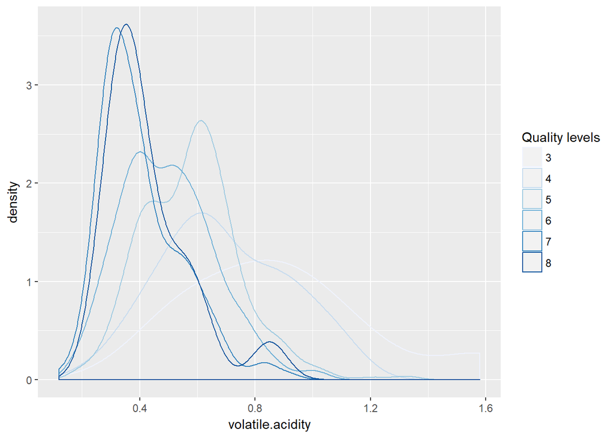

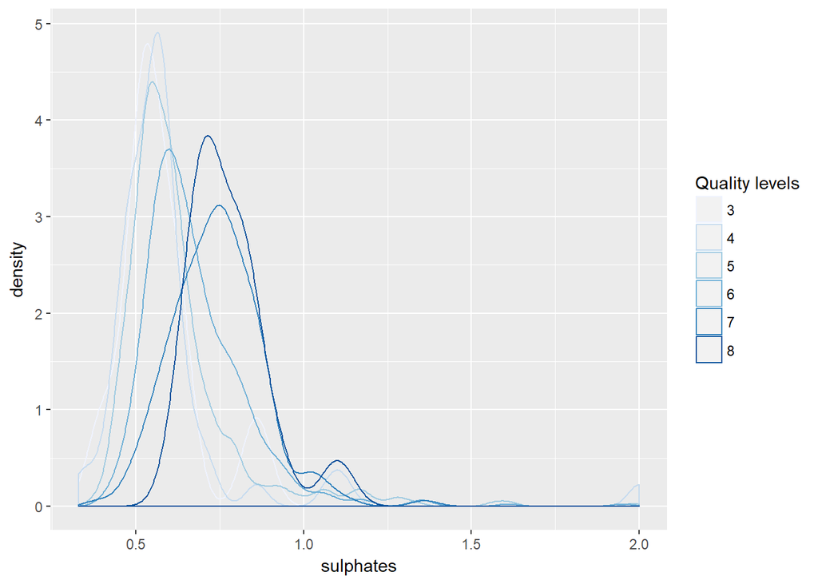

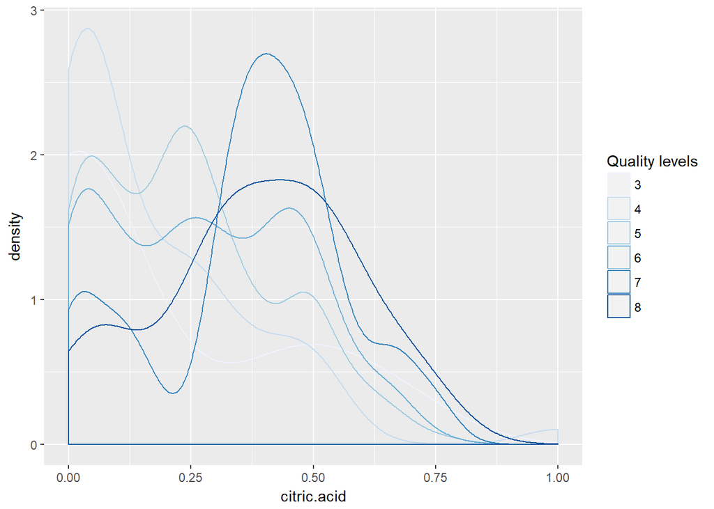

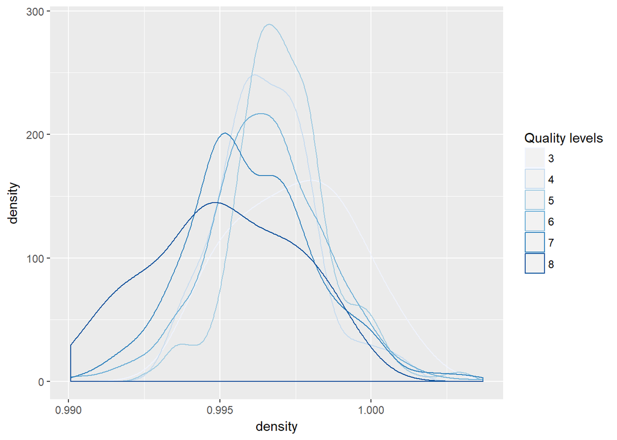

Wines with higher levels of alcohol, sulphates and citric.acid, and lower levels of volatile.acidity and density tend to occur more often at higher quality scores.

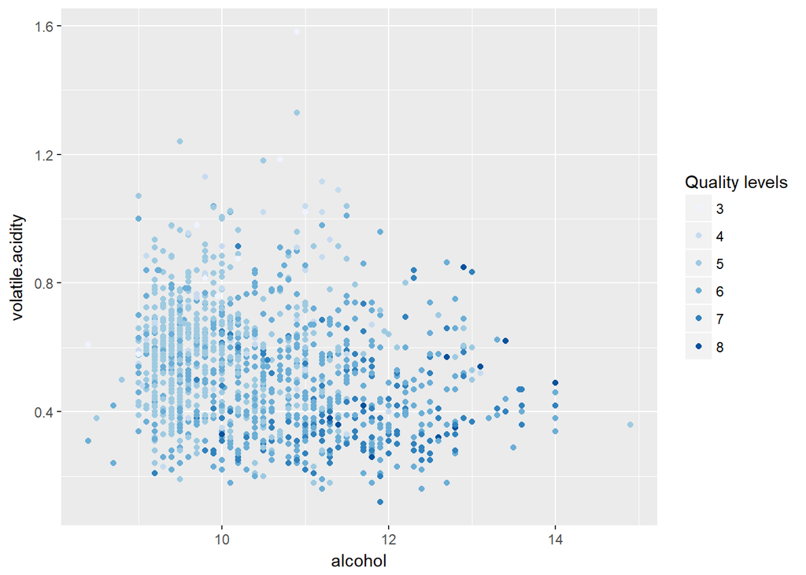

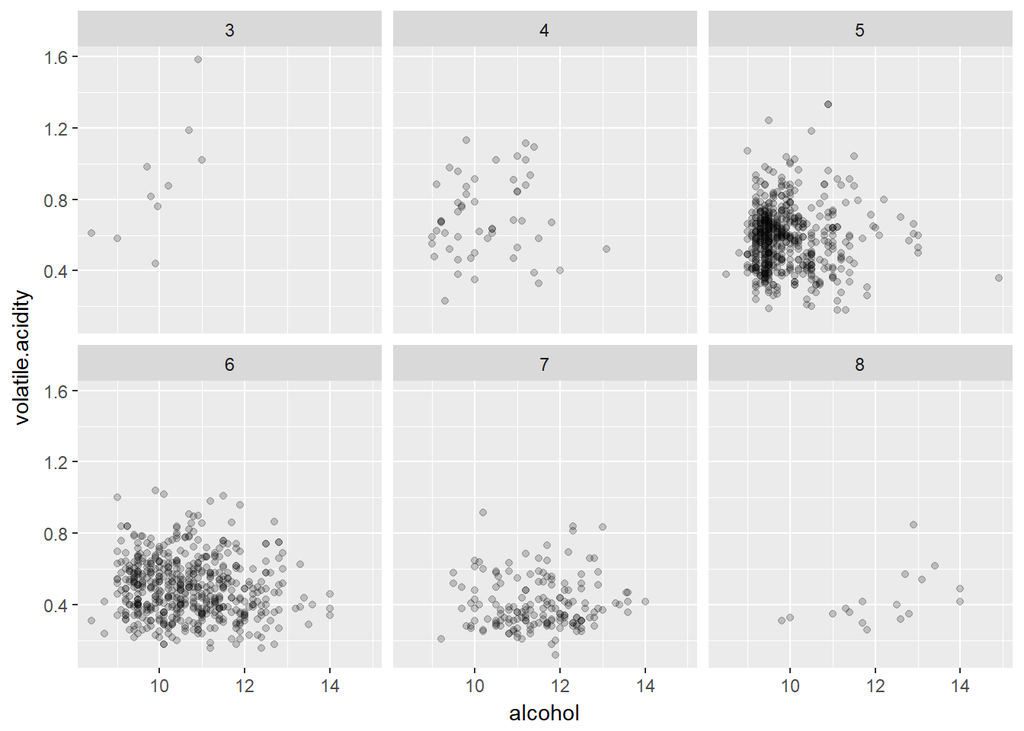

Quality scores of 4, 5, 6, 7 cluster by volatile.acidity and alcohol values, but quality scores of 3 and 8 don’t show much cluster trend from the plot. This is probably because there is very few amount of data in the 3 and 8.

We also notice that better qualities (6, 7, 8) have very few wines with volatile.acidity more than 0.8. In addition, quality scores of 3, 4, 5 have very few wines with alcohol greater than 12.

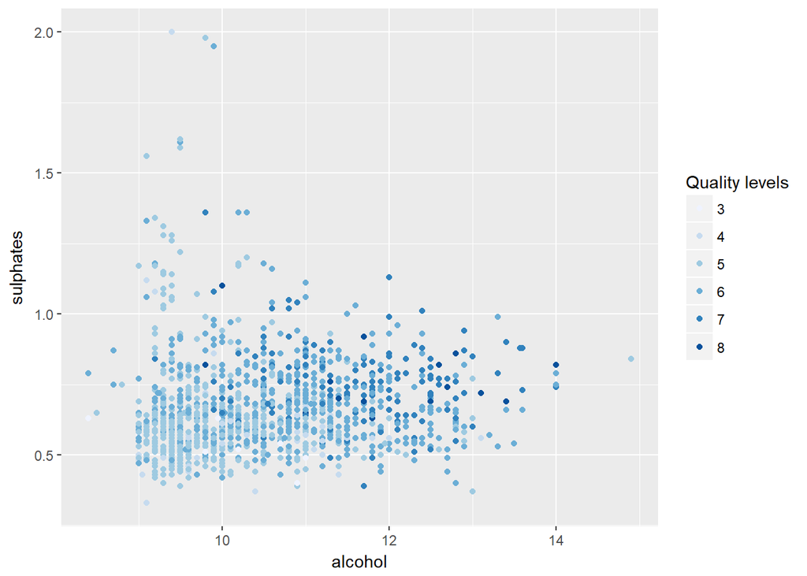

This plot shows that if we keep alcohol constant, the wines with more sulphates tend to have higher quality scores.

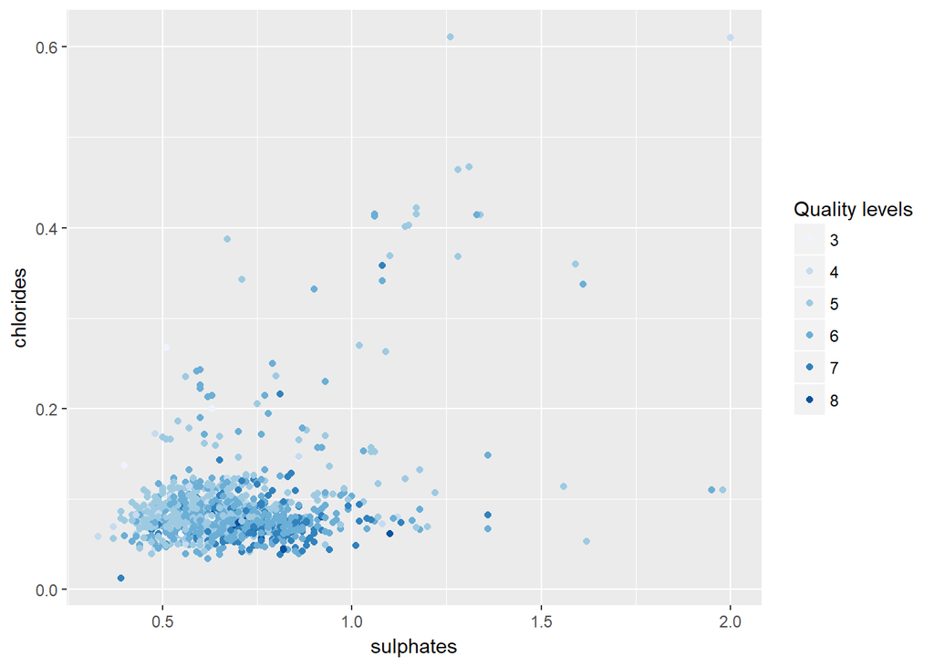

# Multivariate Analysis

### Talk about some of the relationships you observed in this part of the investigation. Were there features that strengthened each other in terms of looking at your feature(s) of interest?

Wines with higher levels of alcohol, sulphates and citric.acid, and lower levels of volatile.acidity and density tend to occur more often at higher quality scores.

Better qualities (6, 7, 8) have very few wines with volatile.acidity more than 0.8. In addition, quality scores of 3, 4, 5 have very few wines with alcohol greater than 12.

If we keep alcohol constant, the wines with more sulphates tend to have higher quality scores.

### Were there any interesting or surprising interactions between features?

Quality scores of 5, 6, 7 cluster by volatile.acidity and alcohol values, and quality scores of 3, 4, and 8 not cluster. It is probably because that there are different amount of wines in each quality scores.

# Final Plots and Summary

### Plot One

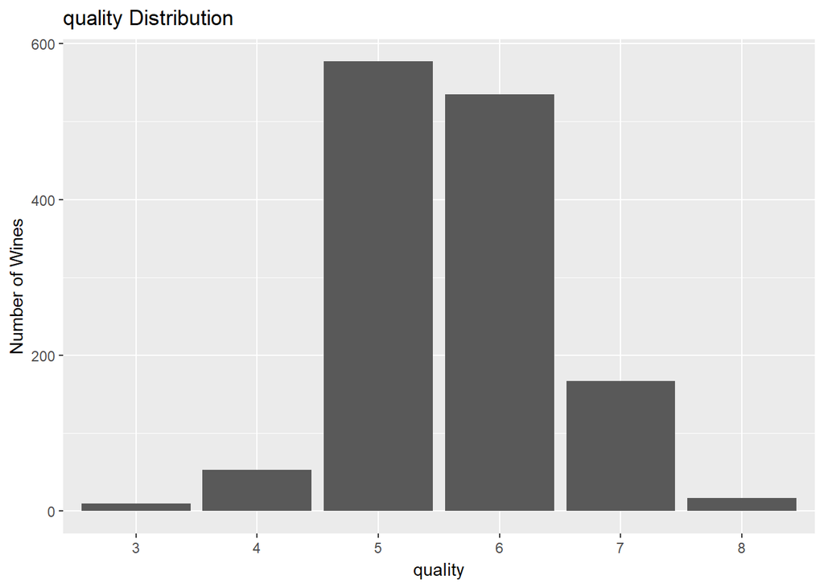

### Description One

The most wines have quality of 5 or 6. The best red wines and the worst wines have least counts compared with other quality scores.

### Plot Two

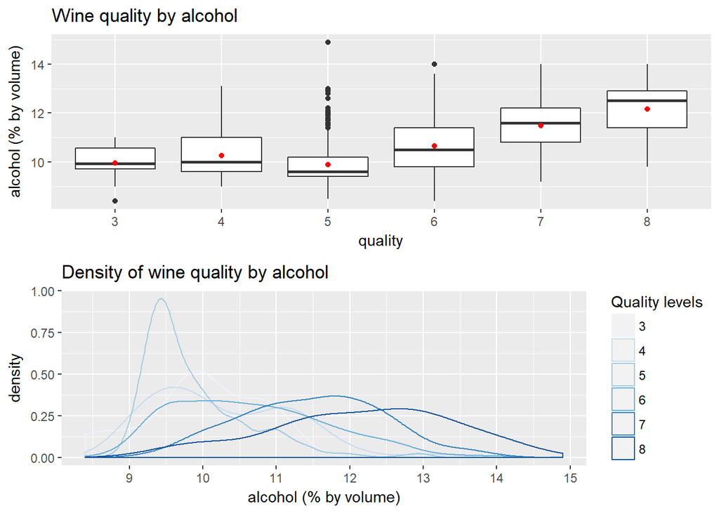

### Description Two

The means and medians of alcohol have increasing trends overall as quality increases. Wines having more alcohol tend to occur more often at higher quality scores. The wines with quality 5 have lowest alcohol median and mean, and they have least alcohol variance in the middle 50%.

### Plot Three

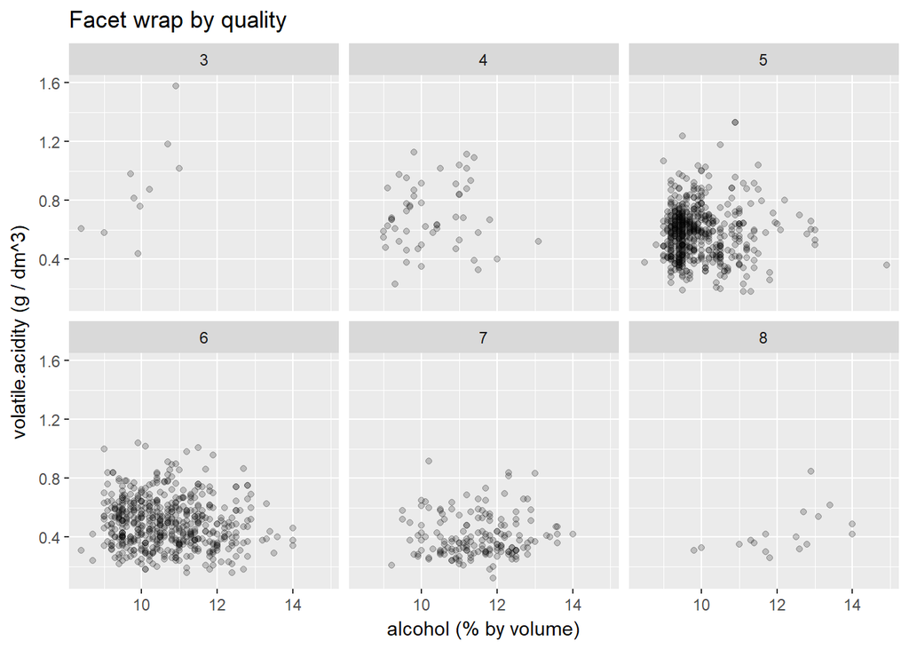

### Description Three

Quality scores of 4, 5, 6, 7 cluster by volatile.acidity and alcohol values, but quality scores of 3 and 8 don’t show much cluster trend from the plot.

We also notice that better qualities (6, 7, 8) have very few wines with volatile.acidity more than 0.8. In addition, quality scores of 3, 4, 5 have very few wines with alcohol greater than 12.

# Reflection

Furthermore, Wines with higher levels of alcohol, sulphates and citric.acid, and lower levels of volatile.acidity and density tend to occur more often at higher quality scores.

One interesting finding is that although free SO2 concentrations over 50 ppm may results that SO2 becomes evident in the nose and taste of wine, they still get not bad quality from 5 to 7.

Another interesting finding is that wines with 0 citric.acid could be in any quality scores except 8.

The struggle is it is the first time for me to handle these many variables at the same time. Sometimes it is a little hard to organize them properly. Until in the middle of analysis, I found all variables could be concluded in: acidity, sulfur dioxide, sugar, salt, and alcohol. Then it is much more clear for me to analyze them.

One limitation about this analysis is we didn’t build any model for quality. Alcohol and volatile.acidity should be the most important components in the model for quality. For the future work in building model, I would try other variables like sulphate or citricacid to improve precision of model.

# Reference

https://www.udacity.com

https://stackoverflow.com